# analysis_fooblyapple

# Install and load packages

```r
#install.packages("tidyverse")
#install.packages("emmeans")
#install.packages("car")
#install.packages("sentimentr")
#install.packages("lmerTest")
#install.packages("performance")

library(tidyverse)
library(emmeans)
library(car)
library(sentimentr)
library(lmerTest)
library(performance)
```

# Import data

```r
sona_data = read.csv("../data/savic-valence.csv") %>%
  select(-sona_id) %>%
  mutate(data_source = "sona")

prolific_data = read.csv("../data/prolificdatanov22.csv")%>%
  select(-PROLIFIC_PID) %>%
  mutate(data_source = "prolific")

final_data = rbind(sona_data, prolific_data) %>%
  mutate(rt = as.numeric(rt)) %>%
  mutate(valence = as.factor(valence)) %>%
  mutate(typeoftrial = as.factor(typeoftrial))
```

# Inspect data

```r
nrow(final_data)
```

```
## [1] 86680
```

```r
ncol(final_data)
```

```
## [1] 43
```

```r
final_data %>%
pull(ID) %>% unique() %>% length
```

```
## [1] 166
```

```r
final_data %>%
  group_by(ID) %>% count()
```

```
## # A tibble: 166 × 2
## # Groups:   ID [166]
##          ID     n
##       <int> <int>
##  1   467275   580
##  2  2310993     1
##  3 20142680   581
##  4 21084574   580
##  5 39410809   584
##  6 45658941    22
##  7 48244800   584
##  8 53369061   119
##  9 58526859   580
## 10 66911944   581
## # ℹ 156 more rows
```

```r
final_data %>%
  group_by(ID) %>% filter(typeoftrial == "target") %>% count()
```

```
## # A tibble: 148 × 2
## # Groups:   ID [148]
##          ID     n
##       <int> <int>
##  1   467275   105
##  2 20142680   105
##  3 21084574   105
##  4 39410809   105
##  5 48244800   105
##  6 58526859   105
##  7 66911944   105
##  8 78773045     7
##  9 81384815   105
## 10 82602209   105
## # ℹ 138 more rows
```

```r
final_data %>%
  group_by(ID) %>% filter(typeoftrial == "target" & block_number == 1)%>% count()
```

```
## # A tibble: 147 × 2
## # Groups:   ID [147]
##          ID     n
##       <int> <int>
##  1   467275    96
##  2 20142680    96
##  3 21084574    96
##  4 39410809    96
##  5 48244800    96
##  6 58526859    96
##  7 66911944    96
##  8 81384815    96
##  9 82602209    96
## 10 90706185    96
## # ℹ 137 more rows
```

```r
final_data %>%
  group_by(ID) %>% filter(typeoftrial == "sentence") %>% count()
```

```
## # A tibble: 161 × 2
## # Groups:   ID [161]
##          ID     n
##       <int> <int>
##  1   467275   126
##  2 20142680   126
##  3 21084574   126
##  4 39410809   126
##  5 45658941    19
##  6 48244800   126
##  7 53369061   111
##  8 58526859   126
##  9 66911944   126
## 10 78773045   126
## # ℹ 151 more rows
```

```r
final_data %>%
  group_by(ID) %>% filter(typeoftrial == "attention") %>% count()
```

```
## # A tibble: 159 × 2
## # Groups:   ID [159]
##          ID     n
##       <int> <int>
##  1   467275     9
##  2 20142680     9
##  3 21084574     9
##  4 39410809     9
##  5 45658941     2
##  6 48244800     9
##  7 53369061     7
##  8 58526859     9
##  9 66911944     9
## 10 78773045     9
## # ℹ 149 more rows
```

There are 86680 rows and 43 columns in our data, and 166 unique subjects. All subjects that completed the experiment completed 105 target trials (9 practice and 96 experimental), 126 sentence trials, and 9 attention trials. All subjects did the same number of trials because unlike in the demographics survey, the number of trials should not change based on the responses of the subject.

Our independent variables are “valence” (positive, negative, neutral) and “type” (novel or familiar). Our dependent variables are “rt” for priming trials.

# Basic descriptives

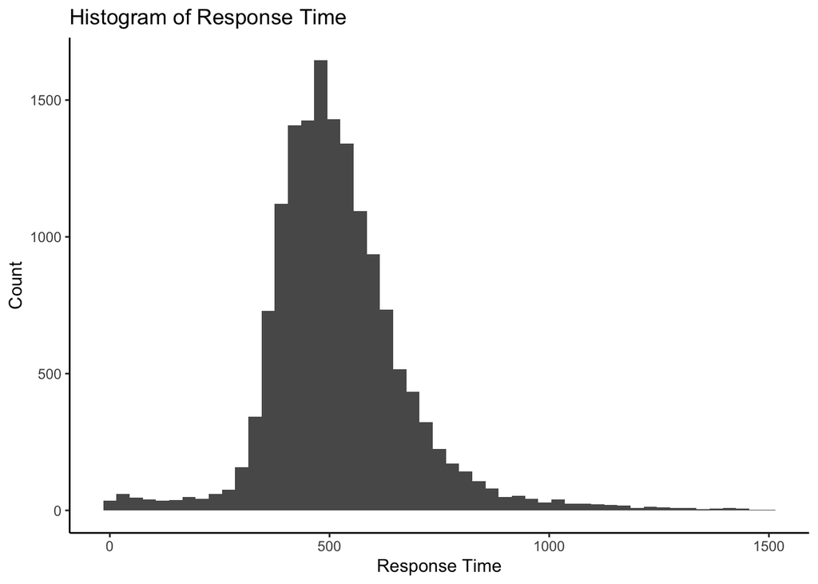

```r
demographics = final_data %>%
 filter(typeoftrial == "demographics") %>%
  select(ID, age, gender, education, race, hispanic, dominant_hand, alert_time, english, age_learned_english) %>%
  mutate(across(c(age, education, age_learned_english), ~ replace_na(., NA))) %>%
  mutate(across(c(age, gender, education, race, hispanic, dominant_hand, alert_time, english),
                ~ ifelse(. == "", "blank", .)))

subject_age = demographics %>%
summarise(mean_age = mean(age, na.rm = TRUE),
            sd_age = sd(age, na.rm = TRUE))

gender_distribution = demographics %>%
  filter(gender != "blank") %>%
  mutate(gender_cleaned = case_when(
    str_trim(gender) %in% c("Female", "female", "F", "FEMALE", "Female.", "Female/woman", "cis-women") ~ "Female",
    str_trim(gender) %in% c("Male", "male", "m", "M") ~ "Male",
    TRUE ~ "Other"
  )) %>%
  count(gender_cleaned)

race_distribution = demographics %>%
  filter(race != "blank") %>%
  count(race)

subject_education = demographics %>%
  summarise(mean_education = mean(education, na.rm = TRUE),
            sd_education = sd(education, na.rm = TRUE))

target_accuracy = final_data %>%
  filter(typeoftrial == "target") %>%
  group_by(ID) %>%
  summarise(correct_count = sum(correct == TRUE, na.rm = TRUE),
    total_count = n(),
    accuracy = correct_count / total_count)

mean_target_accuracy = target_accuracy %>%
  summarise(mean_accuracy = mean(accuracy),
            sd_accuracy = sd(accuracy))

final_data %>%
  filter(typeoftrial == "target") %>%
  filter(rt < 1500) %>%
ggplot()+
  geom_histogram(mapping = aes (x = rt), binwidth = 30, na.rm = TRUE)+
 labs(title = "Histogram of Response Time",
       x = "Response Time",
       y = "Count") +
  theme_classic()
```

Based on the histogram, response times can be represented by a positively-skewed distribution with a peak around 500ms. The tail seems to taper around 1500ms, which we established as a cut-off.

```r
attention = final_data %>%
  filter(typeoftrial == "attention") %>%
  select(ID, response, novel, correct) %>%
  rowwise() %>%
  mutate(response = ifelse(is.na(response), "blank", response)) %>%
mutate(across(c(novel), ~ replace_na(., "NOT_FOUND"))) %>%
  mutate(edit_novel = adist(novel, response))%>%
  mutate(revised_correct = ifelse (edit_novel < 3, 1, 0),
         mismatch = ifelse (correct == revised_correct, 0, 1)) %>%
  ungroup()

subject_attention_accuracy = attention %>%
  group_by(ID) %>%
  summarise(mean_accuracy = mean(revised_correct, na.rm = TRUE),
            sd_accuracy = sd(revised_correct, na.rm = TRUE))
```

The mean age of our sample is 33.91, and the standard deviation is 13.32. The gender distribution is currently 84 females, 60 males, and 3 participants who identified as nonbinary. In terms of the racial distribution, there is 1 subject who identified as American Indian/Alaskan Native, 12 as Asian, 24 as Black/African American, 92 as White/Caucasian, 9 as multiracial, and 9 as other. The mean number of years of education in our sample was 15.07, with a standard deviation of 3.28.

The average accuracy in the target trials was 0.71, with a standard deviation of 0.45.

# Inferential statistics

Primary research question: To what extent does word valence impact word recognition? Operationalized by response times.

```r
low_acc_IDs = subject_attention_accuracy %>%
   filter(mean_accuracy < 0.75) %>%
   select(ID, mean_accuracy)

low_acc_IDs_vector = low_acc_IDs$ID %>%
  length()

revised_critical_data = final_data %>%
  select(ID, rt, condition, prime, correct, target, correct_key, block_number, typeoftrial) %>%
  filter(typeoftrial == "target", block_number == 1) %>%
  filter(!is.na(rt), rt > 200, rt < 1500, correct %in% c("true", "TRUE")) %>%
  anti_join(low_acc_IDs, by = "ID")

included_in_priming = revised_critical_data %>%
  pull(ID) %>%
  unique() %>%
  length()

valence_codes = read_csv("../data/valence_codes.csv")
revised_critical_data = revised_critical_data %>%
  filter(typeoftrial == "target" & block_number == 1)%>%
  select(ID, condition, rt, prime, target, correct) %>%
  left_join(valence_codes) %>% # for foobly, dodish, nuppical, mipp
  filter(!(prime %in% c("boff", "geck")))
revised_critical_data %>%
  group_by(ID) %>% count()
```

```
## # A tibble: 90 × 2
## # Groups:   ID [90]
##          ID     n
##       <int> <int>
##  1 20142680    55
##  2 21084574    24
##  3 39410809    57
##  4 58526859    63
##  5 66911944    62
##  6 81384815    56
##  7 82602209    59
##  8 90706185    59
##  9 93714199    45
## 10 93825956    63
## # ℹ 80 more rows
```

```r
counts = revised_critical_data %>%
  group_by(valence) %>%
  count()
```

Exclusions: The number of participants initially recruited was 166. We excluded 57 participants based on pre-registration criteria, and another 19 for not completing all parts of the experiment. In our models, we analyzed the data from 90 total participants.

```r
mean_scores = revised_critical_data %>%
  group_by(valence) %>%
  summarize(mean_rt = mean(rt),
           sd_rt = sd(rt)) %>%
  left_join(counts) %>%
  mutate(SE = sd_rt/sqrt(n),
         ymin = mean_rt - 1.96*SE,
         ymax = mean_rt + 1.96*SE)
```

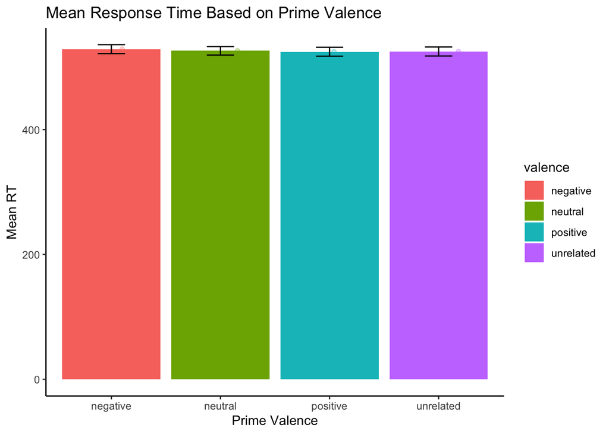

```r
mean_scores %>%
  group_by(valence) %>%
    ggplot() +
    geom_col(mapping = aes(x = valence, y = mean_rt,
                           group = valence, fill = valence),
             position = "dodge")+
  geom_errorbar(aes(x = valence, ymin = ymin, ymax = ymax),
                width = .25,
                position = position_dodge(width=0.9)) +
  geom_point(data = mean_scores, aes(x = valence, y=mean_rt, colour = valence),
             position = position_jitterdodge(),
             alpha = 0.3)+
  labs(title = "Mean Response Time Based on Prime Valence",
       x = "Prime Valence",
       y = "Mean RT") +
    theme_classic()
```

Based on the bar graph, the mean_rt for all valences appear to be equal.

```r
rt_model = lmer(data = revised_critical_data,
                rt ~ valence + (1|ID))
car::Anova(rt_model)
```

```
## Analysis of Deviance Table (Type II Wald chisquare tests)
##
## Response: rt
##         Chisq Df Pr(>Chisq)
## valence 1.884  3     0.5968
```

```r
nobs(rt_model)
```

```
## [1] 4942
```

Our statistical tests indicated that there was no main effect of valence on reaction time, χ2(3, N = 4942) = 1.884, *p* = .597.

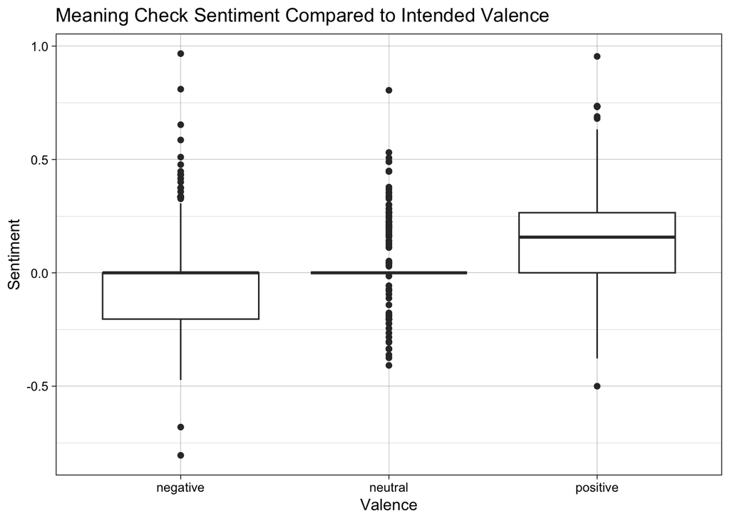

```r
meaning_check = final_data %>%
  filter(typeoftrial == "meaning_check") %>%
  select(ID, condition, response, cue) %>%
  filter(str_count(response, "\\S+") >= 3)

meaning_check_correct = meaning_check %>%
  mutate(prime = str_extract(cue, "\\S+$"),
    correct = if_else(str_detect(str_to_lower(response), str_to_lower(prime)), "TRUE", "FALSE"))

revised_meaning_check = meaning_check_correct %>%
  filter(correct == "TRUE")

#meaning_check_sentiment
mc_sentiment_score = sentiment(revised_meaning_check$response)

aggregated_scores = mc_sentiment_score %>%
  group_by(element_id) %>%
  summarise(sentiment = mean(sentiment),
    word_count = sum(word_count))

meaning_check_sentiment = revised_meaning_check %>%
  mutate(element_id = row_number()) %>%
  left_join(aggregated_scores, by = "element_id") %>%
  select(-element_id, -word_count) %>%
  left_join(valence_codes, by = c("prime", "condition"))

meaning_check_sentiment %>%
  ggplot(aes(x = valence, y = sentiment)) +
  geom_boxplot() +
  theme_linedraw() +
  labs(title = "Meaning Check Sentiment Compared to Intended Valence", x = "Valence", y = "Sentiment")
```

```r
meaning_check_model = lmer(data = meaning_check_sentiment,
                sentiment ~ valence + (1|ID))
car::Anova(meaning_check_model)
```

```
## Analysis of Deviance Table (Type II Wald chisquare tests)
##
## Response: sentiment
##          Chisq Df Pr(>Chisq)
## valence 122.56  2  < 2.2e-16 ***
## ---
## Signif. codes:  0 '***' 0.001 '**' 0.01 '*' 0.05 '.' 0.1 ' ' 1
```

```r
nobs(meaning_check_model)
```

```
## [1] 856
```

```r
emmeans::emmeans(meaning_check_model, pairwise ~ valence, adjust = "tukey")
```

```
## $emmeans
##  valence   emmean     SE  df lower.CL upper.CL
##  negative -0.0382 0.0121 653 -0.06192  -0.0145
##  neutral   0.0331 0.0121 655  0.00942   0.0569
##  positive  0.1434 0.0121 652  0.11975   0.1671
##
## Degrees-of-freedom method: kenward-roger
## Confidence level used: 0.95
##
## $contrasts
##  contrast            estimate     SE  df t.ratio p.value
##  negative - neutral   -0.0713 0.0165 713  -4.311  0.0001
##  negative - positive  -0.1816 0.0165 714 -10.985  <.0001
##  neutral - positive   -0.1103 0.0165 714  -6.671  <.0001
##
## Degrees-of-freedom method: kenward-roger
## P value adjustment: tukey method for comparing a family of 3 estimates
```

Our testing suggested there was a main effect of valence on sentiment score, (χ2(2, N = 856) = 122.56, *p* < .001).

Follow-up Tukey p adjustment tests for pairwise comparison indicate that valence of the priming sentences was significantly predictive of sentiment score for sentences created during meaning check. All pairwise comparisons confirm that these differences are statistically significant (*p*’s < .001). We can conclude that our subjects were largely able to accurately associate novel words with their conditional valence. # Sentence boxplot

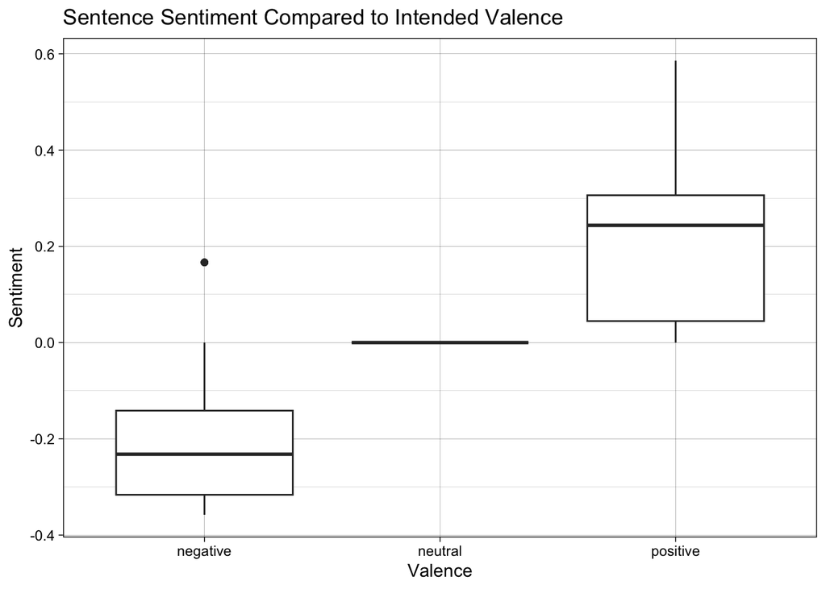

```r
directory = "../Experiment"

all_csv_files = list.files(directory, pattern = "^valence_sentences.*-updated\\.csv$", full.names = TRUE)

sentences = all_csv_files %>%
  purrr::map_dfr(read_csv) %>%
  mutate(element_id = row_number()) %>%
  select(-part)
sentence_sentiment_score = sentiment(sentences$sentence)

aggregated_sentence_scores = sentence_sentiment_score %>%
  group_by(element_id) %>%
  summarise(sentiment = mean(sentiment),
    word_count = sum(word_count))

sentences = sentences %>%
  left_join(aggregated_sentence_scores, by = "element_id") %>%
  select(-word_count)

sentences %>%
  ggplot(aes(x = valence, y = sentiment)) +
  geom_boxplot() +
  theme_linedraw() +
  labs(title = "Sentence Sentiment Compared to Intended Valence", x = "Valence", y = "Sentiment")
```

This boxplot represents the sentiment scores of the sentences used in training and a visual reflection of how our valence groups correlated with sentiment scores. Notably, there is an outlier in the negative valence. This sentence is “I hope they do not have a nuppical apple” which received a sentiment score of 0.16667. This outlier reflects a limitation of sentimentr: a sentence that would be interpreted as negative by a human subject is recorded as positive.